# Data summary of my five flux towers

Author

Merle Braun

Published

November 20, 2026

## Introduction

This report provides an overview of five FLUXNET towers and their half-hourly flux and meteorological measurements. The aim is to assess site characteristics, data coverage and the distribution of key environmental variables.

Timestamps are provided in local standard time without daylight-saving adjustments. UTC is used only as a container for storing timestamps in R.

Missing values (-9999) were converted to NA during data import.

## C1. Site overview

The five selected flux towers represent different geographical locations and ecosystem types.

## C1. Site overview

The five selected FLUXNET towers are located in the United States, Switzerland, Spain, Denmark and Japan.

| Site ID | Site name | Country | IGBP class | Latitude | Longitude | First year | Last year | Network | Data citation |
| --- | --- | --- | --- | --- | --- | --- | --- | --- | --- |
| US-Prr | Poker Flat Research Range Black Spruce Forest | United States | ENF | 65.124 | -147.488 | 2010 | 2022 | AmeriFlux | Hideki Kobayashi, Go Iwahana, Hiroki Ikawa, Naoki Kukuu, Rikie Suzuki (2026), AmeriFlux FLUXNET-1F US-Prr Poker Flat Research Range Black Spruce Forest, Ver. v1.3_r1 (2010-2022), AmeriFlux AMP, (Datas… |
| JP-Hc3 | Hachihama Experimental Farm Double Crop | Japan | CRO | 34.540 | 133.912 | 2005 | 2008 | JapanFlux | Iwata, T., Takimoto, T. (2026). Fluxnet Archive Product from Hachihama Experimental Farm Double Crop, 2005–2008, FLUXNET, https://hdl.handle.net/11676/7mRmcdv3o0cDwldpdIkzLgqj |
| DK-Sor | Soroe | Denmark | DBF | 55.486 | 11.645 | 1996 | 2024 | European Fluxes Database;ICOS | Ibrom, A., Lange Rønn, E., Lodsgaard Justesen, M., Møller, F., Pilegaard, K., Schaarup Sørensen, J. (2026). Fluxnet Archive Product from Soroe, 1996–2024, FLUXNET, https://hdl.handle.net/11676/lwXfRUV… |
| ES-LJu | Llano de los Juanes | Spain | OSH | 36.927 | -2.752 | 2004 | 2024 | European Fluxes Database;GHG-Europe | Domingo, F., Kowalski, A.S., Serrano Ortiz, P., Sánchez-Cañete, E.P. (2026). Fluxnet Archive Product from Llano de los Juanes, 2004–2024, FLUXNET, https://hdl.handle.net/11676/TWomFhgjVCGRurmVpcaHcRD5 |
| CH-Oe3 | Oensingen extensive grassland | Switzerland | GRA | 47.285 | 7.732 | 2002 | 2011 | European Fluxes Database | Ammann, C. (2026). Fluxnet Archive Product from Oensingen extensive grassland, 2002–2011, FLUXNET, https://hdl.handle.net/11676/Jk2_wTjn37nJQ0Ex5QzdqT8D |

### Geographical distribution

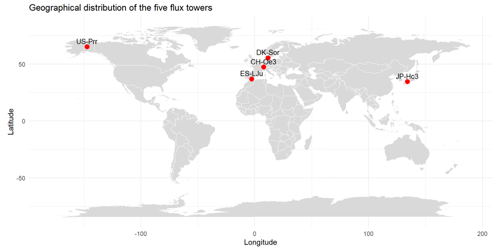

## C2. Data coverage

Data coverage was assessed as the proportion of half-hourly NEE observations that were directly measured (NEE_VUT_REF_QC = 0).

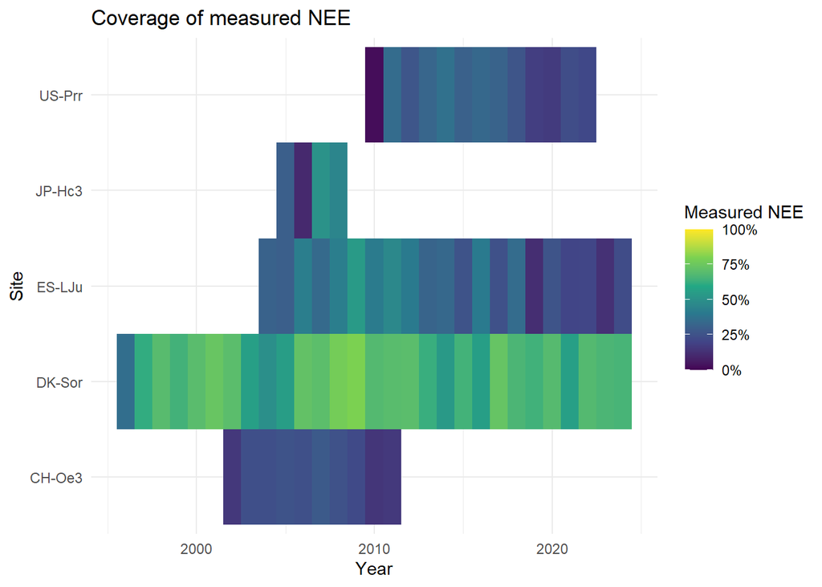

Summary statistics were calculated for the main flux and meteorological variables at each site.

For precipitation, the mean annual sum was calculated using complete years without missing precipitation values.

### CH-Oe3

| Variable | Mean | Mean unit | Minimum | Maximum | Min/Max unit | Missing (%) |
| --- | --- | --- | --- | --- | --- | --- |
| GPP_NT_VUT_REF | 5.09 | µmol CO2/m²/s | -22.37 | 51.27 | µmol CO2/m²/s | 2.09 |
| H_F_MDS | 2.70 | W/m² | -250.12 | 826.03 | W/m² | 2.09 |
| LE_F_MDS | 48.04 | W/m² | -99.00 | 600.69 | W/m² | 2.08 |
| NEE_VUT_REF | -0.70 | µmol CO2/m²/s | -41.02 | 27.77 | µmol CO2/m²/s | 2.09 |
| P_F | 1131.36 | mm/year | 0.00 | 34.81 | mm/30 min | 0.00 |
| RECO_NT_VUT_REF | 4.40 | µmol CO2/m²/s | 0.00 | 23.30 | µmol CO2/m²/s | 2.09 |
| SW_IN_F | 137.40 | W/m² | 0.00 | 1113.00 | W/m² | 0.00 |
| TA_F | 9.31 | °C | -17.37 | 35.24 | °C | 0.00 |
| VPD_F | 3.23 | hPa | 0.00 | 47.10 | hPa | 0.00 |

### DK-Sor

| Variable | Mean | Mean unit | Minimum | Maximum | Min/Max unit | Missing (%) |
| --- | --- | --- | --- | --- | --- | --- |
| GPP_NT_VUT_REF | 5.57 | µmol CO2/m²/s | -42.19 | 67.03 | µmol CO2/m²/s | 2.04 |
| H_F_MDS | 6.00 | W/m² | -300.00 | 749.70 | W/m² | 2.04 |
| LE_F_MDS | 33.75 | W/m² | -248.90 | 779.90 | W/m² | 2.04 |
| NEE_VUT_REF | -0.66 | µmol CO2/m²/s | -62.89 | 44.39 | µmol CO2/m²/s | 2.04 |
| P_F | 793.48 | mm/year | 0.00 | 25.20 | mm/30 min | 0.00 |
| RECO_NT_VUT_REF | 4.91 | µmol CO2/m²/s | 0.00 | 27.44 | µmol CO2/m²/s | 2.04 |
| SW_IN_F | 118.06 | W/m² | 0.00 | 1183.50 | W/m² | 0.00 |
| TA_F | 8.71 | °C | -13.89 | 31.39 | °C | 0.00 |
| VPD_F | 2.52 | hPa | 0.00 | 34.54 | hPa | 0.00 |

### ES-LJu

| Variable | Mean | Mean unit | Minimum | Maximum | Min/Max unit | Missing (%) |
| --- | --- | --- | --- | --- | --- | --- |
| GPP_NT_VUT_REF | NA | µmol CO2/m²/s | NA | NA | µmol CO2/m²/s | 100.00 |
| H_F_MDS | 58.70 | W/m² | -294.61 | 641.71 | W/m² | 4.88 |
| LE_F_MDS | 19.73 | W/m² | -248.67 | 481.52 | W/m² | 4.90 |
| NEE_VUT_REF | -0.08 | µmol CO2/m²/s | -27.23 | 42.18 | µmol CO2/m²/s | 6.78 |
| P_F | 561.84 | mm/year | 0.00 | 63.21 | mm/30 min | 0.00 |
| RECO_NT_VUT_REF | NA | µmol CO2/m²/s | NA | NA | µmol CO2/m²/s | 100.00 |
| SW_IN_F | 190.73 | W/m² | 0.00 | 1312.40 | W/m² | 0.00 |
| TA_F | 11.97 | °C | -40.05 | 46.34 | °C | 0.00 |
| VPD_F | 8.53 | hPa | 0.00 | 49.06 | hPa | 0.00 |

### JP-Hc3

| Variable | Mean | Mean unit | Minimum | Maximum | Min/Max unit | Missing (%) |
| --- | --- | --- | --- | --- | --- | --- |
| GPP_NT_VUT_REF | 2.92 | µmol CO2/m²/s | -48.66 | 51.10 | µmol CO2/m²/s | 63.76 |
| H_F_MDS | 10.47 | W/m² | -244.60 | 513.80 | W/m² | 27.51 |
| LE_F_MDS | 52.70 | W/m² | -294.30 | 643.80 | W/m² | 27.51 |
| NEE_VUT_REF | -2.06 | µmol CO2/m²/s | -49.43 | 48.66 | µmol CO2/m²/s | 28.05 |
| P_F | 4058.71 | mm/year | 0.00 | 27.24 | mm/30 min | 0.00 |
| RECO_NT_VUT_REF | 1.23 | µmol CO2/m²/s | 0.00 | 8.63 | µmol CO2/m²/s | 63.76 |
| SW_IN_F | 171.72 | W/m² | 0.00 | 1146.76 | W/m² | 0.00 |
| TA_F | 15.96 | °C | -325.28 | 36.80 | °C | 0.00 |
| VPD_F | 4.29 | hPa | 0.00 | 32.57 | hPa | 0.00 |

### US-Prr

| Variable | Mean | Mean unit | Minimum | Maximum | Min/Max unit | Missing (%) |
| --- | --- | --- | --- | --- | --- | --- |
| GPP_NT_VUT_REF | 1.49 | µmol CO2/m²/s | -11.72 | 40.43 | µmol CO2/m²/s | 9.72 |
| H_F_MDS | 14.28 | W/m² | -264.74 | 414.01 | W/m² | 7.73 |
| LE_F_MDS | 16.23 | W/m² | -61.71 | 329.06 | W/m² | 9.70 |
| NEE_VUT_REF | 0.08 | µmol CO2/m²/s | -35.08 | 17.23 | µmol CO2/m²/s | 9.71 |
| P_F | 400.78 | mm/year | 0.00 | 12.50 | mm/30 min | 0.00 |
| RECO_NT_VUT_REF | 1.57 | µmol CO2/m²/s | 0.00 | 9.98 | µmol CO2/m²/s | 9.72 |
| SW_IN_F | 110.42 | W/m² | 0.00 | 1048.79 | W/m² | 0.00 |
| TA_F | -1.89 | °C | -48.53 | 36.62 | °C | 0.00 |
| VPD_F | 3.27 | hPa | 0.00 | 48.01 | hPa | 0.00 |

## C4. Time series

Half-hourly measurements of NEE, GPP and RECO were aggregated to daily means and converted from µmol CO2 m-2 s-1 to g C m-2 d-1 using a conversion factor of 1.0378.

Only days with 48 valid half-hourly values per variable were included in the daily aggregation.

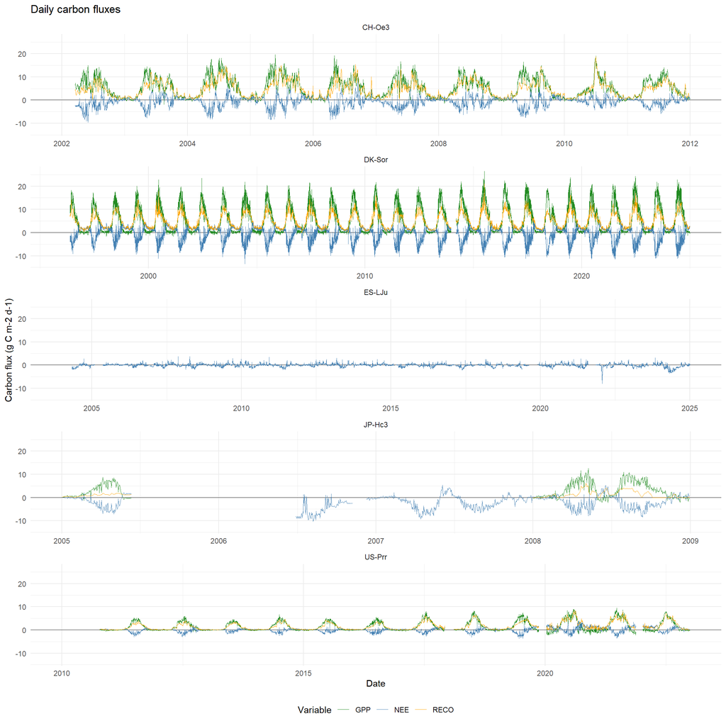

### Validation against FLUXMET_DD

The calculated daily NEE values were compared with the official daily FLUXMET product for one site.

| Site | Days_compared | Correlation | Mean_absolute_difference |
| --- | --- | --- | --- |
| US-Prr | 4284 | 0.9949 | 0.0489 |

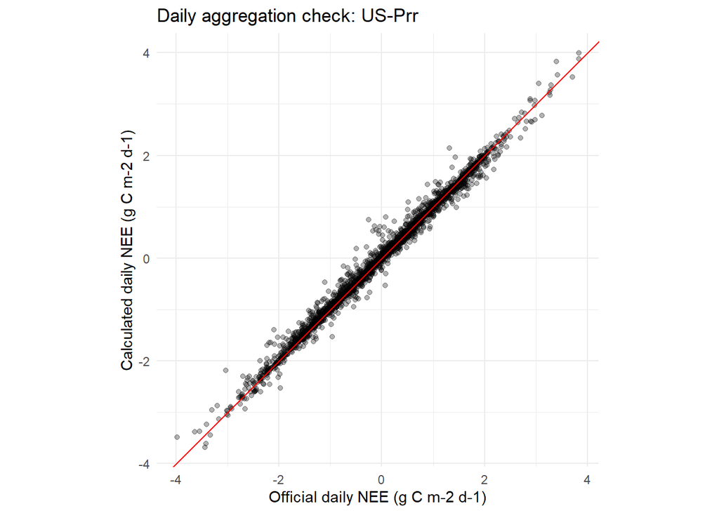

## C5. Diurnal cycles

Mean diurnal cycles of NEE and latent heat flux (LE) were calculated for each site and season.

Meteorological seasons were defined using the latitude of each site. For sites in the Southern Hemisphere, seasons were reversed relative to the Northern Hemisphere.

All five selected sites are located in the Northern Hemisphere.

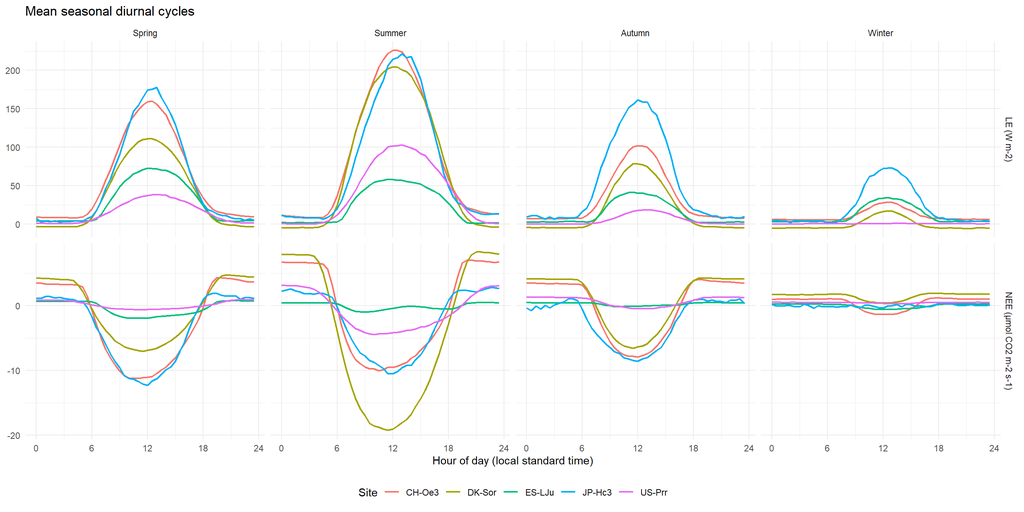

## C6. Interpretation

### C6.1. Energy balance closure

Energy balance closure was assessed by comparing the sum of sensible and latent heat fluxes (H + LE) with available energy (NETRAD - G).

Only half-hourly observations with directly measured H and LE values (QC = 0) and available radiation and ground heat flux data were included.

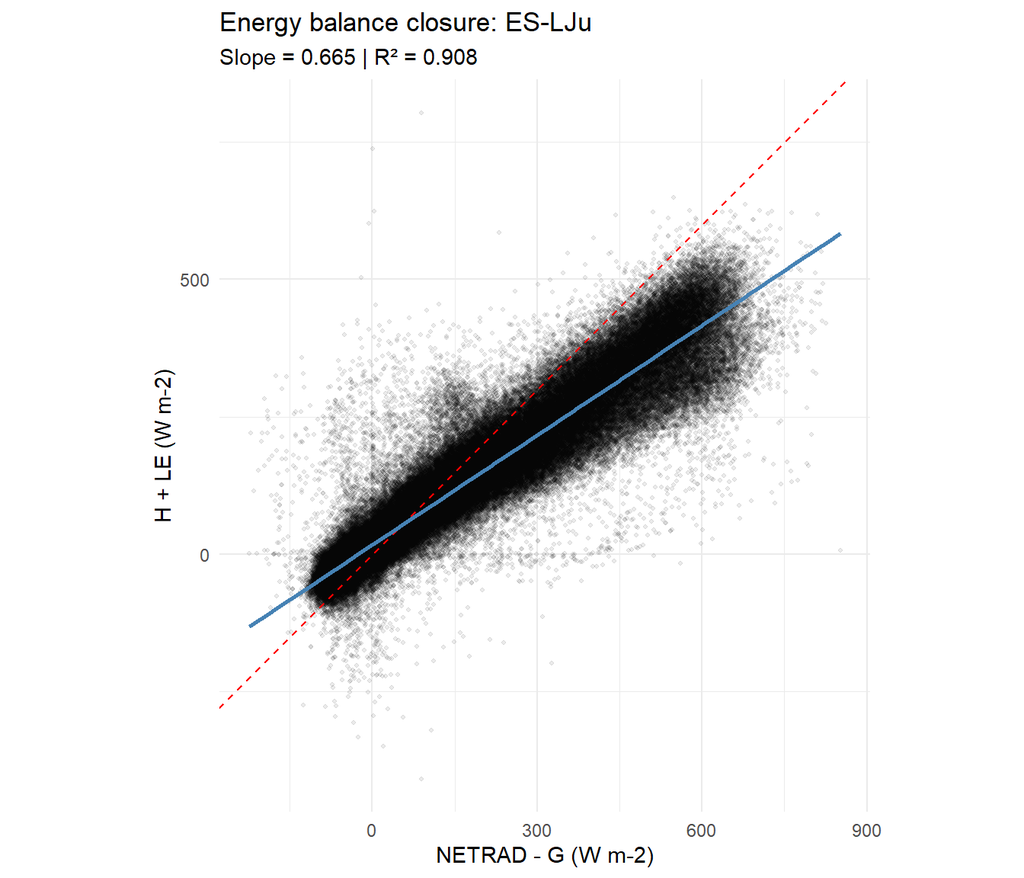

The energy balance was evaluated at site ES-LJu, using 249954 valid half-hourly observations.

The slope of the linear regression was 0.665, with an R-squared of 0.908.

### C6.2. Comparison of the five sites

| Site | Complete years | Mean annual NEE (g C m-2 yr-1) |
| --- | --- | --- |
| JP-Hc3 | 2 | -665.41 |
| DK-Sor | 26 | -233.07 |
| CH-Oe3 | 9 | -232.92 |
| US-Prr | 6 | -32.86 |
| ES-LJu | 12 | -22.65 |

| Site | Seasonal NEE amplitude (g C m-2 d-1) |
| --- | --- |
| DK-Sor | 8.78 |
| JP-Hc3 | 7.43 |
| CH-Oe3 | 4.28 |
| US-Prr | 2.07 |
| ES-LJu | 1.28 |

| Site | Measured (%) | Gap-filled (%) | Missing or unknown (%) |
| --- | --- | --- | --- |
| CH-Oe3 | 22.05 | 75.86 | 2.09 |
| DK-Sor | 65.07 | 32.88 | 2.04 |
| ES-LJu | 32.08 | 61.15 | 6.78 |
| JP-Hc3 | 34.26 | 37.68 | 28.05 |
| US-Prr | 25.91 | 64.38 | 9.71 |

Among the five investigated sites, JP-Hc3 showed the highest annual net carbon uptake. In contrast, ES-LJu showed the lowest net carbon uptake. The largest seasonal variation in NEE was observed at DK-Sor. Differences between the sites may be related to vegetation type, climatic conditions and the length of the growing season. The diurnal cycles revealed differences in carbon uptake and latent heat flux between seasons. I was particularly surprised by high carbon storage of the cropland in Japan. The proportion of gap-filled NEE data varied considerably between the sites, ranging from 32.88 % to 75.86%.

## Data and citation

### Site-specific data citations

**US-Prr**: Hideki Kobayashi, Go Iwahana, Hiroki Ikawa, Naoki Kukuu, Rikie Suzuki (2026), AmeriFlux FLUXNET-1F US-Prr Poker Flat Research Range Black Spruce Forest, Ver. v1.3_r1 (2010-2022), AmeriFlux AMP, (Dataset). https://doi.org/10.17190/AMF/2571106

**JP-Hc3**: Iwata, T., Takimoto, T. (2026). Fluxnet Archive Product from Hachihama Experimental Farm Double Crop, 2005–2008, FLUXNET, https://hdl.handle.net/11676/7mRmcdv3o0cDwldpdIkzLgqj

**DK-Sor**: Ibrom, A., Lange Rønn, E., Lodsgaard Justesen, M., Møller, F., Pilegaard, K., Schaarup Sørensen, J. (2026). Fluxnet Archive Product from Soroe, 1996–2024, FLUXNET, https://hdl.handle.net/11676/lwXfRUVQCnuq5OcIe-F6tpib

**ES-LJu**: Domingo, F., Kowalski, A.S., Serrano Ortiz, P., Sánchez-Cañete, E.P. (2026). Fluxnet Archive Product from Llano de los Juanes, 2004–2024, FLUXNET, https://hdl.handle.net/11676/TWomFhgjVCGRurmVpcaHcRD5

**CH-Oe3**: Ammann, C. (2026). Fluxnet Archive Product from Oensingen extensive grassland, 2002–2011, FLUXNET, https://hdl.handle.net/11676/Jk2_wTjn37nJQ0Ex5QzdqT8D

### FLUXNET methodology

Pastorello, G., et al. (2020). The FLUXNET2015 dataset and the ONEFlux processing pipeline for eddy covariance data. Scientific Data, 7, 225.

https://doi.org/10.1038/s41597-020-0534-3

##Git hub link https://github.com/braunmer/datascience_env_monit/tree/main/reports